# 從 RStudio 搬到 Positron（Posit Academy 繁中筆記）

把買了看不完的線上課程，一鍵變成能讀完的筆記。

# 從 RStudio 搬到 Positron（Posit Academy 繁中筆記）

把買了看不完的線上課程，一鍵變成能讀完的筆記。

**1**門課程**8**篇筆記**一鍵**自動整理

## 從 RStudio 搬到 Positron（20 分）

· 8 篇

**🗺️ 本課地圖（點單元標題可跳到那一篇）**

| 用 Command Palette 找到任何指令 | **在 Positron 裡不用記按鈕在哪：按 ⌘⇧P 打開 Command Palette、打關鍵字、按 Enter，就能執行任何指令。這是搬家最值得養成的第一個習慣。** |
| --- | --- |
| 帶著 RStudio 快捷鍵過來 | **打開 `workbench.keybindings.rstudioKeybindings` 這一個設定並重新載入視窗，整套 RStudio 快捷鍵就能在 Positron 照常使用。** |
| 打開你的專案、安排版面 | **Positron 的專案就是「一個資料夾開成一個視窗」，不需要 `.Rproj`；版面則從內建預設（Stacked／Side-by-Side／Notebook）挑一個最像 RStudio 的再微調。** |
| 換上熟悉的配色 | **用 *Preferences: Color Theme* 可以一邊移動一邊即時預覽配色，按 Enter 才套用；想要 RStudio 經典配色，就裝 Tomorrow Night Bright (R Classic) 擴充套件。** |
| 用 Air 自動排版程式碼 | **Positron 內建 R 排版工具 Air，打開 `editor.formatOnSave` 之後，每次存檔程式碼就會自動排整齊。** |
| 用程式碼片段與擴充套件重複利用 | **Snippet 幫你插入現成的程式碼骨架，擴充套件市集比 RStudio addins 大得多，而大部分既有的 RStudio addins 也能用 *R: Run RStudio Addin* 直接在 Positron 執行。** |
| 搞清楚和 RStudio 哪裡不一樣 | **Positron 目前還缺三樣東西（重啟保留工作區、效能分析與套件開發窗格、點選式資料匯入），每樣都有替代做法；而它也多了 RStudio 做不到的六項能力。** |
| 課程總結 | **搬家完成：用 Command Palette 找指令、沿用 RStudio 快捷鍵、版面與配色都調成熟悉的樣子、存檔自動排版，而且全都在你原本的專案裡做完。** |

### 用 Command Palette 找到任何指令

從 RStudio 搬到 Positron · 第 1 單元

一句話總結

**在 Positron 裡不用記按鈕在哪：按 ⌘⇧P 打開 Command Palette、打關鍵字、按 Enter，就能執行任何指令。這是搬家最值得養成的第一個習慣。**

你會學到

- 怎麼打開 Command Palette 並搜尋任何 Positron 指令
- 為什麼它能取代 RStudio 大部分的按鈕和選單
- 內建的「從 RStudio 搬到 Positron」互動導覽在哪裡

開始前

需要已安裝 Positron 並開著一個專案。還沒裝可到 https://positron.posit.co/download.html 下載。

### 內容筆記

#### 從「找按鈕」改成「打字搜尋」

在 RStudio，想做某件事時你會去找按鈕、翻選單，或用背好的快捷鍵。Positron 一樣有上百個指令，但不需要記每個指令藏在哪，只要記一個入口：**Command Palette（指令面板）**，一個可以搜尋 Positron 所有 IDE 指令的清單。

1. 按 **⌘⇧P**（Windows／Linux 是 Ctrl+Shift+P）打開 Command Palette。
2. 開始打關鍵字，模糊搜尋會邊打邊列出符合的指令。
3. 用方向鍵選擇，按 **Enter** 執行。

[figure not shown]

Positron 開著 Command Palette：畫面正上方彈出搜尋框，下方列出符合關鍵字的指令清單，有快捷鍵的指令會在右側顯示按鍵組合

馬上試

打開 Command Palette，輸入 *Toggle Primary Side Bar* 後按 Enter。

**成功的樣子**：左側的側邊欄消失；再執行一次就會回來。你沒有碰任何按鈕就完成了一個動作。

#### 為什麼這是最重要的習慣

這門課接下來幾乎每一步都用同一個起手式：**打開 Command Palette，打出你想做的事**。這個反射動作可以取代你在 RStudio 找按鈕的大部分肌肉記憶。課程目標是讓你上完課時，不加思索就會先按 ⌘⇧P。

內建的搬家導覽

Positron 內建一份互動導覽 **Migrating from RStudio to Positron**。在 Command Palette 搜尋 *Welcome: Open Walkthrough* 就能打開，可以當這門課的速查手冊。打開它的方式本身就是在練習用 Command Palette。

#### 怎麼確認學會了

不碰選單或按鈕，就能打開 Command Palette、用關鍵字找到指令並執行。

### 關鍵詞

- **Command Palette（指令面板）**：⌘⇧P 打開的搜尋框，列出 Positron 所有可執行的指令
- **Fuzzy finder（模糊搜尋）**：不需要打完整指令名稱，打部分關鍵字就會列出相符的指令
- **Primary Side Bar（主側邊欄）**：視窗左側顯示檔案、搜尋、Git 等內容的區域

### 可執行要點

- 用 ⌘⇧P 打開 Command Palette，執行 *Toggle Primary Side Bar* 兩次
- 搜尋 *Welcome: Open Walkthrough*，打開「Migrating from RStudio to Positron」導覽
- 接下來一週，想找功能時先按 ⌘⇧P，不要先找按鈕

📝 隨堂測驗（點選項作答）

在 Positron 想執行某個功能但不知道按鈕在哪，課程建議的第一步是？

Command Palette 列出所有 IDE 指令，是課程反覆強調的唯一入口。

內建的「從 RStudio 搬到 Positron」導覽要怎麼打開？

### 帶著 RStudio 快捷鍵過來

從 RStudio 搬到 Positron · 第 2 單元

一句話總結

**打開 `workbench.keybindings.rstudioKeybindings` 這一個設定並重新載入視窗，整套 RStudio 快捷鍵就能在 Positron 照常使用。**

你會學到

- 怎麼一次開啟整套 RStudio 快捷鍵
- 沿用 RStudio 快捷鍵與改學 Positron 原生快捷鍵的取捨
- 怎麼從 Command Palette 查看與修改任一指令的快捷鍵

開始前

需要會開啟與搜尋 Command Palette（第 1 單元）。

### 內容筆記

#### 肌肉記憶不用丟

你的手指已經習慣用 ⌘Enter 執行一行、用 ⌘⇧M 插入 pipe。怕失去這些肌肉記憶，是 RStudio 使用者最常見的效率焦慮，所以課程第一件事就是解決它。

很多 RStudio 快捷鍵在 Positron 本來就能用。另外只要開一個設定，就能啟用**整套** RStudio 快捷鍵。如果你主要用的是 RStudio，課程建議打開。

#### 四步開啟

1. 打開 Command Palette，搜尋 *Preferences: Open Settings (UI)*。
2. 在設定頁搜尋 `rstudioKeybindings`。
3. 勾選 `workbench.keybindings.rstudioKeybindings`。
4. 從 Command Palette 執行 *Developer: Reload Window* 重新載入。

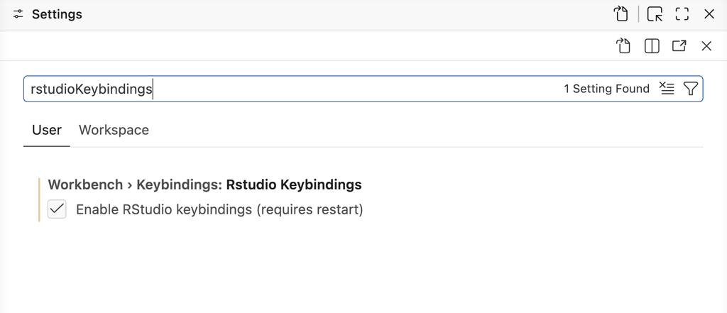

Positron 設定頁搜尋 rstudioKeybindings 後只找到一項：「Workbench › Keybindings: Rstudio Keybindings — Enable RStudio keybindings (requires restart)」，勾選框已打勾

馬上試

照上面四步做完後，按 **Ctrl+1** 游標應該跳到編輯器，按 **Ctrl+2** 跳到 Console，和 RStudio 一樣。

開啟後，你熟悉的 RStudio 快捷鍵大多可以原樣使用。

#### 另一個選擇：直接學 Positron 原生快捷鍵

如果想從一開始就學 Positron 原生的快捷鍵，就不要開這個設定。Positron 有完整的快捷鍵參考，以及 R 專用快捷鍵說明可查。

查看與修改快捷鍵

有快捷鍵的指令，在 Command Palette 裡會顯示在指令旁邊。滑鼠移到指令上會出現齒輪圖示，點它就能修改那個指令的快捷鍵。

### 可執行要點

- 決定要沿用 RStudio 快捷鍵，還是改學 Positron 原生快捷鍵
- （沿用的話）在設定開啟 `workbench.keybindings.rstudioKeybindings`
- 執行 *Developer: Reload Window*，用 Ctrl+1／Ctrl+2 確認生效

📝 隨堂測驗（點選項作答）

開啟 rstudioKeybindings 之後還要做什麼才會生效？

設定說明寫明 requires restart，課程用 Developer: Reload Window 重新載入。

開啟成功後，Ctrl+2 會做什麼？

### 打開你的專案、安排版面

從 RStudio 搬到 Positron · 第 3 單元

一句話總結

**Positron 的專案就是「一個資料夾開成一個視窗」，不需要 `.Rproj`；版面則從內建預設（Stacked／Side-by-Side／Notebook）挑一個最像 RStudio 的再微調。**

你會學到

- 不靠 `.Rproj` 也能打開既有的 RStudio 專案
- Activity Bar 與 Primary Side Bar 分別對應 RStudio 的哪些窗格
- 怎麼試用內建版面預設，挑一個最接近你 RStudio 習慣的

開始前

需要會開啟與搜尋 Command Palette（第 1 單元）。

### 內容筆記

#### 打開既有專案

RStudio 是雙擊 `.Rproj` 檔來開專案。Positron 的 **workspace（工作區）** 就是在獨立視窗裡打開一個資料夾：概念一樣，只是不需要那個特殊檔案。

1. 打開 Command Palette，執行 *File: Open Folder*（或選單 **File › Open Folder**）。
2. 選擇專案資料夾。

也可以在該資料夾的終端機裡執行 `positron .`。

[figure not shown]

Positron 歡迎畫面上打開資料夾的幾個入口（以橘框標示）：工具列的 Open 按鈕與其下拉選單（New Folder、Open Folder、最近開過的資料夾清單）

- 原本的 `.Rproj` 可以留著，Positron 會忽略它。
- 如果用 Git，`.git/` 資料夾仍會標示專案根目錄，`here` 套件等工具的路徑照常運作。

馬上試

在 Command Palette 搜尋 *File: Open Recent*，重新打開一個你平常在用的專案。

**成功的樣子**：專案在自己的視窗打開，Explorer 列出你的檔案，完全不需要 `.Rproj`。再執行一次 *File: Open Recent* 就能回到上一個專案。

專案設定存在哪

Positron 把專案專屬設定存在 `.vscode/settings.json`，而且只有在你設定了專案專屬選項時才會建立這個檔。Positron 沒有對應 `.Rproj` 的檔案，也不需要。

#### 對應 RStudio 的窗格

RStudio 固定分成四個窗格。Positron 用的是同樣的元件（編輯器、Console，以及 Variables、Plots 等窗格），但用兩個控制項來安排：

- **Activity Bar（活動列）**：最左側那排圖示，決定 Primary Side Bar 要顯示什麼。
- **Primary Side Bar（主側邊欄）**：依目前選中的圖示，顯示檔案、搜尋、Git、擴充套件等內容。

| Activity Bar 圖示 | RStudio 對應 |
| --- | --- |
| Explorer | Files 窗格與文件大綱（Outline） |
| Search | **Edit › Find in Files** 或 ⌘⇧F |
| Source Control | Git 窗格 |
| Debugger | 除錯模式下的 Debugging 窗格 |
| Test Explorer | RStudio 沒有對應功能 |
| Posit Assistant | Posit Assistant 聊天視窗 |
| Publisher | Publishing Wizard（發佈精靈） |
| Packages | Packages 窗格 |

[figure not shown]

Positron 介面五大區塊標示圖：最左一排圖示是 Activity Bar；旁邊的檔案清單是 Primary Side Bar；中上方是 Editor（編輯器）；中下方是 Panel（Console、Terminal 等）；最右邊放 Variables 與 Plots 的是 Secondary Side Bar

#### 挑一個版面預設

Positron 的版面比 RStudio 有彈性，課程建議先從內建預設開始，再慢慢調整。

馬上試

在 Command Palette 輸入 `layout`，依序試 **Stacked**、**Side-by-Side**、**Notebook** 三種預設。

**成功的樣子**：窗格會立即重新排列。留下最像你 RStudio 習慣的那個；任何窗格也都可以拖到新位置。

其他調整方式：

- 用右上角的版面按鈕調整
- 把分頁從一個窗格拖到另一個窗格
- 拖動窗格邊界改變大小

[figure not shown]

Positron 右上角的版面按鈕：最左一顆是 Customize Layout（自訂版面），右邊三顆分別切換顯示或隱藏左側欄、下方面板、右側欄

完整選項請看 Positron 文件的「Customize the Layout」。

### 關鍵詞

- **Workspace（工作區）**：在獨立視窗打開的一個資料夾，就是 Positron 的「專案」
- **Activity Bar（活動列）**：最左側圖示列，切換主側邊欄的內容
- **Primary Side Bar（主側邊欄）**：顯示檔案、搜尋、Git、擴充套件的左側區域
- **Secondary Side Bar（次側邊欄）**：右側放 Variables、Plots 等的區域
- **Layout preset（版面預設）**：Stacked、Side-by-Side、Notebook 三種內建排列

### 可執行要點

- 用 *File: Open Folder* 或 *File: Open Recent* 打開一個既有 RStudio 專案
- 確認 `here()` 等路徑照常運作（有 `.git/` 就會）
- 試 Stacked／Side-by-Side／Notebook 三種版面，留一個最順手的

📝 隨堂測驗（點選項作答）

在 Positron 開舊的 RStudio 專案，需要怎麼處理 .Rproj？

RStudio 的 Git 窗格，在 Positron 對應哪個 Activity Bar 圖示？

Positron 的專案專屬設定存在哪裡？

### 換上熟悉的配色

從 RStudio 搬到 Positron · 第 4 單元

一句話總結

**用 *Preferences: Color Theme* 可以一邊移動一邊即時預覽配色，按 Enter 才套用；想要 RStudio 經典配色，就裝 Tomorrow Night Bright (R Classic) 擴充套件。**

你會學到

- 怎麼即時預覽 Positron 的配色主題，確定了再套用
- 想要 RStudio 經典配色時去哪裡找

### 內容筆記

#### 熟悉的顏色很重要

配色熟悉，搬家的陌生感就少一大半。

- 喜歡 RStudio 預設的編輯器配色：安裝 **Tomorrow Night Bright (R Classic)** 主題，第 6 單元（擴充套件）會教怎麼裝。
- 其他情況：Positron 內建了幾十種主題可選。

馬上試

在 Command Palette 搜尋 *Preferences: Color Theme*，用方向鍵在清單上下移動。

**成功的樣子**：整個編輯器會隨著你移動即時換色，套用前就能先看到效果。選定後按 Enter。

（原課程此處附一段示範影片，內容就是上面這個操作。）

### 可執行要點

- 執行 *Preferences: Color Theme*，用方向鍵預覽幾種主題後按 Enter 套用
- 想要 RStudio 經典深色配色，等第 6 單元裝 Tomorrow Night Bright (R Classic)

### 用 Air 自動排版程式碼

從 RStudio 搬到 Positron · 第 5 單元

一句話總結

**Positron 內建 R 排版工具 Air，打開 `editor.formatOnSave` 之後，每次存檔程式碼就會自動排整齊。**

你會學到

- 用 Air 排版整個 R、Quarto 或 R Markdown 檔，或只排選取範圍
- 打開「存檔時自動排版」，讓排版自動發生

開始前

需要會開啟與搜尋 Command Palette（第 1 單元）。

### 內容筆記

#### Air：內建的 R 排版工具

在 RStudio 裡，你可能手動調整格式，或用 styler 套件。Positron 直接內建 **Air**（https://posit-dev.github.io/air/），支援 `.R`、`.qmd`、`.Rmd` 三種檔案，不用另外安裝。

| 想做的事 | Command Palette 指令 |
| --- | --- |
| 排版整個檔案 | *Format Document* |
| 只排版選取的程式碼 | *Format Selection* |

#### 建議：存檔時自動排版

課程建議打開 **Format on Save**，每次存檔都自動整理，連快捷鍵都不用記。

馬上試

1. 在 Command Palette 搜尋 *Preferences: Open Settings (UI)*，打開 `editor.formatOnSave`。
2. 打開一個 R 檔，故意把空格弄亂，按 ⌘S 存檔。

**成功的樣子**：一存檔，Air 就把程式碼排整齊。

使用者設定 vs. 工作區設定

這個設定要套用到你所有專案（使用者設定），還是只套用到目前專案（工作區設定），可參考 Air 官方文件的說明。

### 關鍵詞

- **Air**：Positron 內建的 R 程式碼排版工具，作用類似 styler
- **Format on Save**：`editor.formatOnSave`，存檔時自動排版

### 可執行要點

- 在設定開啟 `editor.formatOnSave`
- 打開一個空格凌亂的 R 檔存檔，確認會自動排整齊
- 決定這個設定要放在使用者層級，還是只放在某個專案

📝 隨堂測驗（點選項作答）

Air 支援哪些檔案類型？

想讓每次存檔都自動排版，要開哪個設定？

### 用程式碼片段與擴充套件重複利用

從 RStudio 搬到 Positron · 第 6 單元

一句話總結

**Snippet 幫你插入現成的程式碼骨架，擴充套件市集比 RStudio addins 大得多，而大部分既有的 RStudio addins 也能用 *R: Run RStudio Addin* 直接在 Positron 執行。**

你會學到

- 插入與自訂程式碼片段（snippet）
- 尋找與安裝擴充套件，包括 RStudio 經典配色主題
- 在 Positron 執行既有的 RStudio addin

開始前

需要會開啟與搜尋 Command Palette（第 1 單元）。

### 內容筆記

#### 程式碼片段（Snippets）

Snippet 會插入常用寫法的現成範本。例如打 `for` 後選擇對應的 snippet，就會插入：

[output not shown]

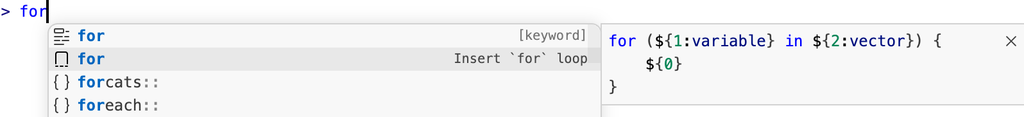

在 R 檔打 for 之後跳出的自動完成清單，其中有一項是 for 迴圈的 snippet，可以選擇插入

Positron 內建 R 保留字的 snippet：`if`、`while`、`for`、`function`。

馬上試

在 R 檔打 `for`，從自動完成清單選 snippet，再按 Tab 逐一跳過佔位符。

**成功的樣子**：游標依序從 `variable` 跳到 `vector`，再跳到迴圈內容。

**自訂 snippet**：在 Command Palette 執行 *Snippets: Configure Snippets*。

格式不同

Positron 用 TextMate snippet 語法，和 RStudio 的格式不同。RStudio 預設 snippet 已經有人轉成 Positron 格式，放在 GitHub 上 posit-dev/ark 專案的 `r.code-snippets` 檔，可以直接參考。

#### 擴充套件（Extensions）

擴充套件可以替 Positron 增加預設以外的功能，角色類似 RStudio addins，但市集大得多。

打開方式：點 Activity Bar 的 Extensions 圖示，或在 Command Palette 執行 *Extensions: Focus on Extensions View*，再用名稱或關鍵字搜尋。

R 使用者常用的擴充套件：

| 擴充套件 | 用途 |
| --- | --- |
| Tomorrow Night Bright (R Classic) | 移植到 Positron 的 RStudio 深色主題 |
| Indent-Rainbow | 用顏色區分縮排層級 |
| Rainbow CSV | 用顏色區分 CSV 欄位，方便編輯 |
| GitHub Actions | 在 IDE 裡操作 GitHub Actions |
| GitLab Workflow | GitLab 支援 |
| Project Manager | 快速切換專案 |

馬上試

執行 *Extensions: Focus on Extensions View*，搜尋「Tomorrow Night Bright (R Classic)」，按 **Install**。

**成功的樣子**：在 *Preferences: Color Theme* 裡可以選它，編輯器變成 RStudio 經典深色配色。想回到 Posit 預設配色，在清單捲到 **Light** 區選回即可。

[figure not shown]

擴充套件管理員的安裝流程：在 Activity Bar 點 Extensions 圖示，於左側搜尋框輸入名稱，點搜尋結果查看詳細頁，再按藍色 Install 按鈕安裝 Tomorrow Night Bright (R Classic)

- 你也可以用 TypeScript／JavaScript 寫自己的擴充套件，能做到的事遠超過 RStudio addins。
- 很多軟體公司提供免費擴充套件，讓你在 Positron 裡使用他們的服務，例如 SAS、Snowflake、Databricks、DuckDB。工作上有用到的軟體，可以先到市集搜尋看看。

#### 執行既有的 RStudio addins

Positron 透過 `rstudioapi` 套件的相容層（shims）支援大部分 RStudio addins。在 Command Palette 執行 *R: Run RStudio Addin* 即可。例如裝了 `reprex` 套件後，就能從這裡啟動它的 addin 來製作可重現範例。

### 關鍵詞

- **Snippet（程式碼片段）**：打關鍵字就能插入的程式碼範本，用 Tab 在佔位符之間跳
- **TextMate snippet 語法**：Positron（及 VS Code）的 snippet 格式，與 RStudio 不同
- **Extension（擴充套件）**：從市集安裝的外掛，功能類似但多於 RStudio addins
- **rstudioapi shims**：讓 RStudio addins 能在 Positron 執行的相容層

### 可執行要點

- 在 R 檔試一次 `for` snippet，用 Tab 走完佔位符
- 把你在 RStudio 自訂的 snippet 改寫成 TextMate 格式，用 *Snippets: Configure Snippets* 加入
- 安裝 Tomorrow Night Bright (R Classic)，或其他你需要的擴充套件
- 用 *R: Run RStudio Addin* 試跑一個你常用的 addin（例如 reprex）

📝 隨堂測驗（點選項作答）

插入 snippet 後，要怎麼在佔位符之間移動？

RStudio 的 snippet 檔可以直接複製到 Positron 用嗎？

想在 Positron 執行既有的 RStudio addin，要用哪個指令？

### 搞清楚和 RStudio 哪裡不一樣

從 RStudio 搬到 Positron · 第 7 單元

一句話總結

**Positron 目前還缺三樣東西（重啟保留工作區、效能分析與套件開發窗格、點選式資料匯入），每樣都有替代做法；而它也多了 RStudio 做不到的六項能力。**

你會學到

- 哪些 RStudio 功能 Positron 還沒有，以及替代做法
- Positron 有哪些 RStudio 沒有的能力

### 內容筆記

#### Positron 還沒有的（目前）

搬家要有信心，就要清楚知道邊界在哪，之後才不會被嚇到。如果下面任何一項是你工作流程的必需品，那項工作繼續用 RStudio 完全合理。

| RStudio 有、Positron 還沒有 | 替代做法 |
| --- | --- |
| 重新啟動時保留工作區狀態：Positron 每次都從乾淨的 session 開始，不會存回並重新載入 | 靠腳本重建狀態 |
| 效能分析（profiling）與套件開發的專用窗格、按鈕 | 底層工具仍可在 Console 與 Command Palette 使用 |
| 點選式資料匯入介面 | 用 `readr` 或 `readxl` 寫程式匯入；進度在 GitHub（posit-dev/positron issue #5515）追蹤 |

#### Positron 能做、RStudio 做不到的

| 能力 | 說明 |
| --- | --- |
| 多個 R 版本與多個 session | 同一個視窗就能切換不同 R 版本，同時開多個 R session |
| 當掉可以單獨恢復 | session 當掉時開一個新的就好，不必重開整個 IDE |
| Python 也是一等公民 | 資料科學支援與 R 同等，還能在同一個 session 同時跑 R 和 Python |
| 內建 Data Explorer | 直接檢視資料框與 CSV、Parquet 等檔案，不用額外設定 |
| 大型擴充套件市集 | 有 SAS、Snowflake、Databricks 等第三方工具 |
| 遠端 session | 在 Posit Workbench 上，介面留在本機，運算在遠端伺服器 |

找不到某個按鈕時

如果想念 RStudio 的某個按鈕或窗格，先到 Command Palette 找。Positron 幾乎所有動作都在那裡，而且你熟悉的快捷鍵通常也能用。

### 可執行要點

- 對照「還沒有的」三項，確認你的工作流程是否必須用到；必要的那項先留在 RStudio 做
- 改掉依賴「重啟保留工作區」的習慣，讓腳本能從頭重建所有物件
- 資料匯入改寫成 `readr`／`readxl` 程式碼
- 試一次 Data Explorer 打開 CSV 或 Parquet 檔

📝 隨堂測驗（點選項作答）

Positron 重新啟動後，原本 session 裡的物件會怎樣？

課程建議靠腳本重建狀態。

在 Positron 沒有點選式資料匯入介面時，課程建議怎麼做？

下列哪一項是 Positron 有、RStudio 沒有的能力？

### 課程總結

從 RStudio 搬到 Positron · 第 8 單元

一句話總結

**搬家完成：用 Command Palette 找指令、沿用 RStudio 快捷鍵、版面與配色都調成熟悉的樣子、存檔自動排版，而且全都在你原本的專案裡做完。**

你學到了

- 用 Command Palette 找任何指令，不再翻按鈕或選單
- 開啟 RStudio 快捷鍵，肌肉記憶照常可用
- 不靠 `.Rproj` 打開既有專案，並把版面、配色調成熟悉的樣子
- 用 Air 自動排版，用 snippet、擴充套件與 RStudio addins 重複利用程式碼
- 知道 Positron 還缺哪些 RStudio 功能，以及多了哪些 RStudio 沒有的能力

### 內容筆記

#### 你完成了什麼

你已經把「家」重新布置好了：Command Palette 是你的萬用入口，鍵盤肌肉記憶帶過來了，版面和配色都很熟悉，程式碼存檔時還會自動排好。這些都是在你本來就在做的專案裡完成的，這就是你之後的工作環境。

#### 下一步可以深入的主題

- 在 Positron 裡使用 R
- Quarto 文件
- Data Explorer
- Command Palette

### 可執行要點

- 回頭確認前面每一課的設定都已完成
- 挑一個「下一步」主題繼續學（例如 Data Explorer 或 Quarto）

由 Course2Notes 自動生成 · 內容為使用者自有課程的個人學習筆記

[figure not shown]